# Time Series: A First Course with Bootstrap Starter

# Lesson 1-3: Windows and Transforms

- To better visualize a time series, we may examine sub-spans, or use a transformation.

## Windowing

- Focusing on a sub-section of the time series is called *windowing*.
- A *window* has a fixed width, and the starting and ending times change as it slides through the data.
- Windowing is useful for exploratory analysis, to visualize changes.

## Example 1.3.2. Industrial Production

- Industrial Production is a monthly time series, starting in 1949.
- It has strong trend and moderate seasonality.

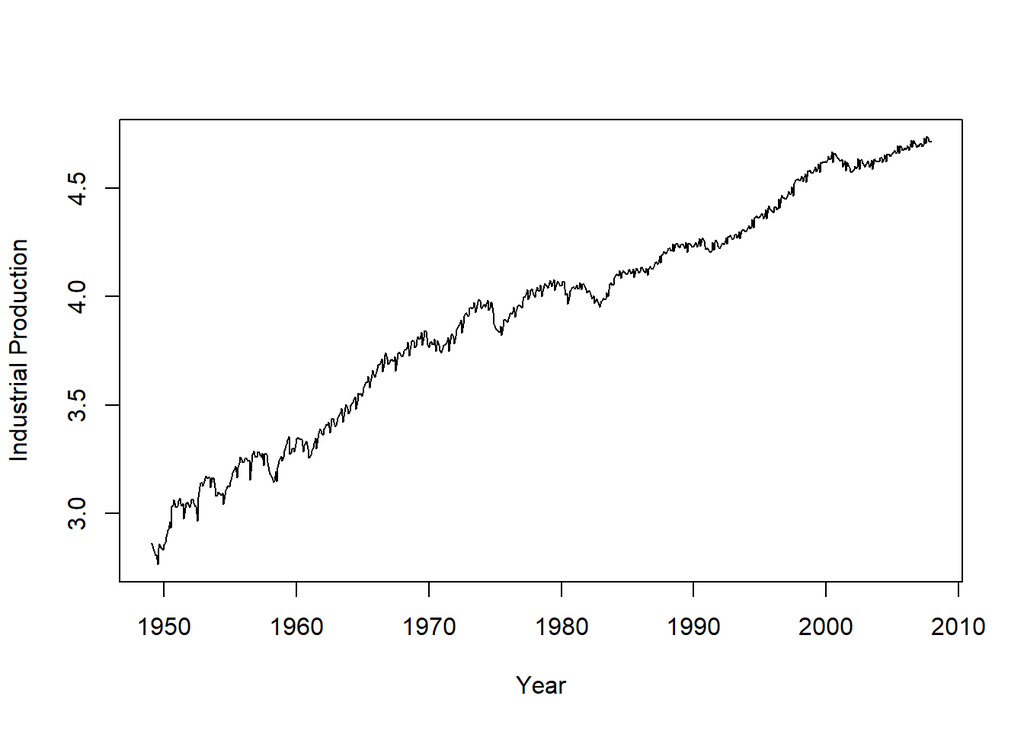

```r
indprod <- read.table("ind.dat")
indprod <- ts(indprod,start=1949,frequency=12)
plot(indprod,xlab="Year",ylab="Industrial Production")
```

- We can create a moving window through the data.

```r
### Movie
movie <- FALSE
delay <- 0
window <- 20
n <- length(indprod)/12
if(movie) {
for(t in 1:(n-window +1))
{
  Sys.sleep(delay)
  subsamp <- indprod[((t-1)*12+1):((t-1+window)*12)]
  newyear <- 1948 + t
  plot(ts(subsamp,start=newyear,frequency=12),ylab="")
} }
```

## Log Transformation

- To visualize and model time series better, sometimes we apply a log transform (if the data is positive).
- If cycle amplitude depends on trend level, applying a log may separate this effect so that cycle amplitude is no longer growing.
- Some extreme effects can be attenuated through the log transform.

## Example 1.3.4. Gasoline Sales

- Monthly measurements of sales at gasoline stations.
- Variation depends on level, so we apply a log transformation.

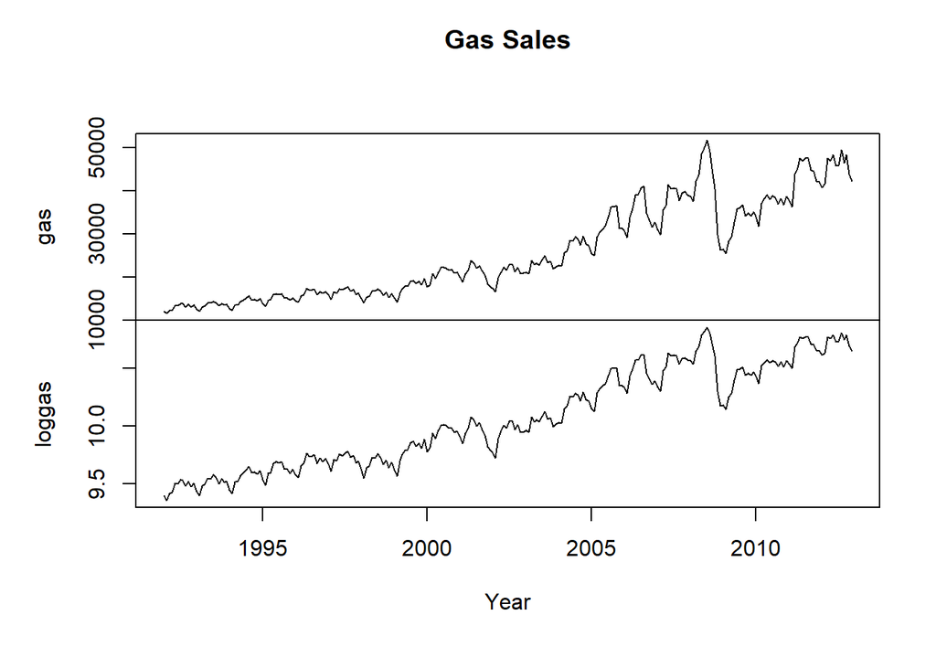

```r
gas <- read.table("GasRaw_2-11-13.dat")[,1]
loggas <- log(gas)
gas_trans <- ts(cbind(gas,loggas),start = 1992,frequency=12)
plot(gas_trans,xlab="Year",main="Gas Sales")
```

## Example 1.3.5. Electronics and Appliance Stores

- Monthly measurements of sales at electronics stores
- Large seasonal movements due to December sales
- We apply a log transformation

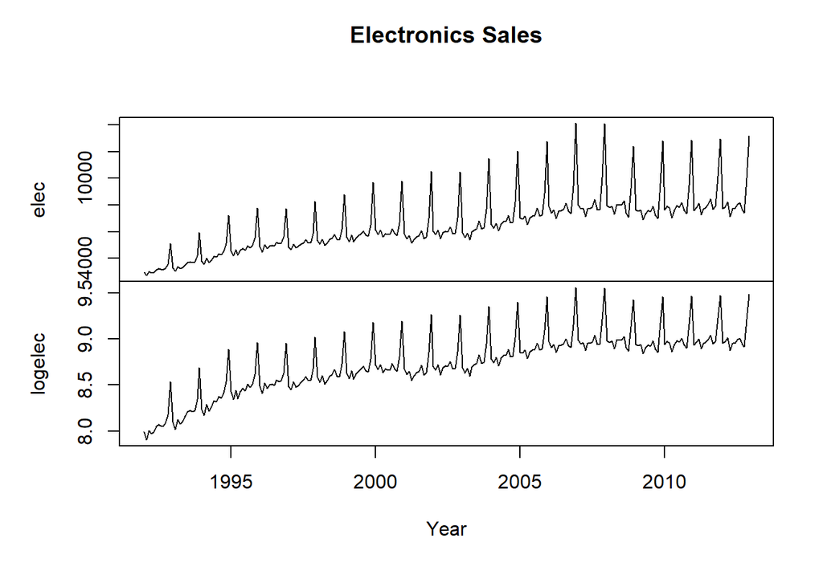

```r
elec <- read.table("retail443.b1",header=FALSE,skip=2)[,2]
logelec <- log(elec)
elec_trans <- ts(cbind(elec,logelec),start = 1992,frequency=12)
plot(elec_trans, xlab="Year",main="Electronics Sales")
```